# Monitoreo Espacio-Temporal de la variación de los Glaciares Maladeta y Monte Perdido (Pirineos, España): Una Perspectiva Geomática

Mireya Fernández

Cargar las librerías necesarias

```r
setwd("E:/TFG/Series Temporales/Codigo/datos/limpio")

library(readr)
library(dplyr)
library(ggplot2)
library(lubridate)
library(readxl)
library(tidyverse)
library(tseries)
library(forecast)
library(tsoutliers)
library(expsmooth)
library(tsutils)
library (zoo)
library(imputeTS)
library(forecast)
library(MASS)
```

# Estación de Torla-Ordesa

## Temperatura

```r
# Leer el archivo CSV con separador ;
datosTorla =read.csv("E:/TFG/Series Temporales/Codigo/datos/limpio/torla.csv",sep = ";")

# Verificar las primeras filas del dataframe original para entender el contenido
print(head(datosTorla))
```

|  | fecha | indicativo | p_max | nw_55 | w_racha | np_100 | nw_91 | np_001 | w_rec | np_300 | p_mes | w_med | np_010 | hr | tm_min | ta_max | ts_min | nt_30 | ta_min | e | nt_00 | ti_max | tm_mes | tm_max | X | X.1 | X.2 |
| --- | --- | --- | --- | --- | --- | --- | --- | --- | --- | --- | --- | --- | --- | --- | --- | --- | --- | --- | --- | --- | --- | --- | --- | --- | --- | --- | --- |
| 1 | ene-06 | 9814A |  | NA |  | NA |  | NA | NA |  | NA | NA | NA |  | NA |  | NA | NA |  | NA | NA | NA | NA | NA | NA | NA | NA |
| 2 | feb-06 | 9814A | 23.1(19) | 0 | 05/11.7(27) | 3 | 0.0 | 7 | 70 | 0.0 | 76.9 | 3 | 6 |  | -1.7 | 15.9(08) | 4.2 | 0 | -6.4(25) | 51 | 24 | 2.2 | 3.9 | 9.4 | NA | NA | NA |
| 3 | mar-06 | 9814A | 40.6(10) | 6 | 32/23.9(05) | 4 | 0.0 | 18 | 121 | 1.0 | 137.9 | 5 | 15 |  | 2.3 | 19.8(31) | 7.5 | 0 | -5.1(01) | 66 | 4 | 3.9 | 7.3 | 12.2 | NA | NA | NA |
| 4 | abr-06 | 9814A | 15.4(14) | 0 | 35/15.0(28) | 2 | 0.0 | 10 | 119 | 0.0 | 48.4 | 4 | 6 |  | 5.0 | 22.4(26) | 11.1 | 0 | -0.7(11) | 78 | 1 | 12.8 | 11.0 | 17.0 | NA | NA | NA |
| 5 | may-06 | 9814A |  | NA |  | NA |  | NA | NA |  | NA | NA | NA |  | NA |  | NA | NA |  | NA | NA | NA | NA | NA | NA | NA | NA |
| 6 | jun-06 | 9814A |  | NA |  | NA |  | NA | NA |  | NA | NA | NA |  | NA |  | NA | NA |  | NA | NA | NA | NA | NA | NA | NA | NA |

```r
# Verificar la estructura del dataframe original
print(str(datosTorla))
```

```
'data.frame':   216 obs. of  27 variables:
 $ fecha     : chr  "ene-06" "feb-06" "mar-06" "abr-06" ...
 $ indicativo: chr  "9814A" "9814A" "9814A" "9814A" ...
 $ p_max     : chr  "" "23.1(19)" "40.6(10)" "15.4(14)" ...
 $ nw_55     : num  NA 0 6 0 NA NA NA NA NA NA ...
 $ w_racha   : chr  "" "05/11.7(27)" "32/23.9(05)" "35/15.0(28)" ...
 $ np_100    : num  NA 3 4 2 NA NA NA NA NA NA ...
 $ nw_91     : chr  "" "0.0" "0.0" "0.0" ...
 $ np_001    : num  NA 7 18 10 NA NA NA NA NA NA ...
 $ w_rec     : num  NA 70 121 119 NA NA NA NA NA NA ...
 $ np_300    : chr  "" "0.0" "1.0" "0.0" ...
 $ p_mes     : num  NA 76.9 137.9 48.4 NA ...
 $ w_med     : num  NA 3 5 4 NA NA NA NA NA NA ...
 $ np_010    : num  NA 6 15 6 NA NA NA NA NA NA ...
 $ hr        : chr  "" "" "" "" ...
 $ tm_min    : num  NA -1.7 2.3 5 NA NA NA NA NA NA ...
 $ ta_max    : chr  "" "15.9(08)" "19.8(31)" "22.4(26)" ...
 $ ts_min    : num  NA 4.2 7.5 11.1 NA NA NA NA NA NA ...
 $ nt_30     : num  NA 0 0 0 NA NA NA NA NA NA ...
 $ ta_min    : chr  "" "-6.4(25)" "-5.1(01)" "-0.7(11)" ...
 $ e         : num  NA 51 66 78 NA NA NA NA NA NA ...
 $ nt_00     : num  NA 24 4 1 NA NA NA NA NA NA ...
 $ ti_max    : num  NA 2.2 3.9 12.8 NA NA NA NA NA NA ...
 $ tm_mes    : num  NA 3.9 7.3 11 NA NA NA NA NA NA ...
 $ tm_max    : num  NA 9.4 12.2 17 NA NA NA NA NA NA ...
 $ X         : num  NA NA NA NA NA NA NA NA NA NA ...
 $ X.1       : num  NA NA NA NA NA NA NA NA NA NA ...
 $ X.2       : num  NA NA NA NA NA NA NA NA NA NA ...
NULL
```

```r
# Verificar cuantos valores NA hay en las columnas seleccionadas
print(colSums(is.na(datosTorla[, c("fecha", "tm_mes")])))
```

```
 fecha tm_mes
     0     83
```

Creamos la serie temporal, con los datos originales

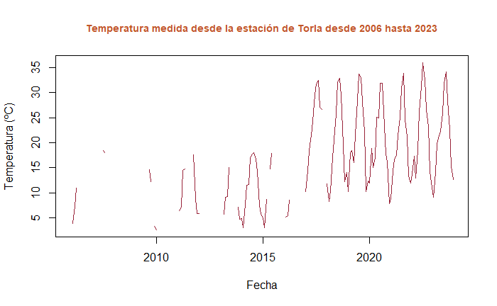

```r
temp_ts=ts(datosTorla$tm_mes, start=2006, frequency = 12)

plot(temp_ts, pch=19, type="l",ylab="Temperatura (ºC)", xlab="Fecha", main="Temperatura medida desde la estación de Torla desde 2006 hasta 2023", cex.main = 0.9, col="#992339",  col.main = "#c15628")
```

### **Interpolación**

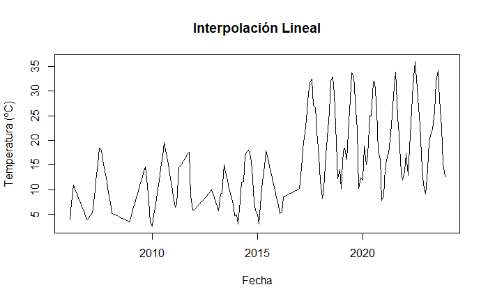

```r
# Método 1: Interpolación lineal
temp_ts_linear <- na.approx(temp_ts)
plot(temp_ts_linear, main="Interpolación Lineal", ylab="Temperatura (ºC)", xlab="Fecha")
```

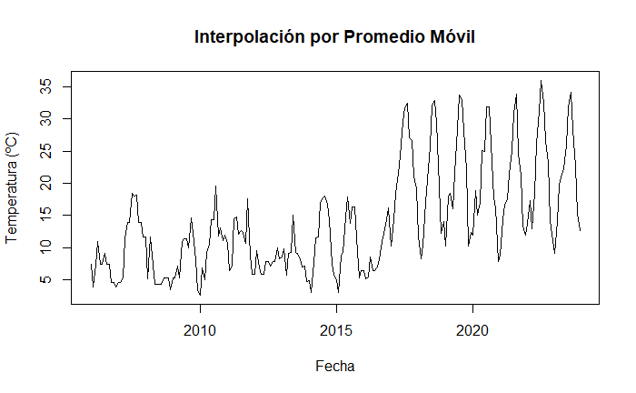

```r
# Método 2: Interpolación por promedio móvil
temp_ts_ma <- na.ma(temp_ts, k=4, weighting="simple")
plot(temp_ts_ma, main="Interpolación por Promedio Móvil", ylab="Temperatura (ºC)", xlab="Fecha")
```

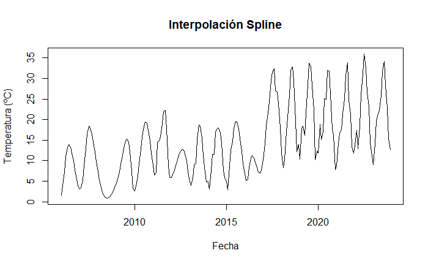

```r
# Método 3: Interpolación spline
temp_ts_spline <- na.spline(temp_ts)
plot(temp_ts_spline, main="Interpolación Spline", ylab="Temperatura (ºC)", xlab="Fecha")
```

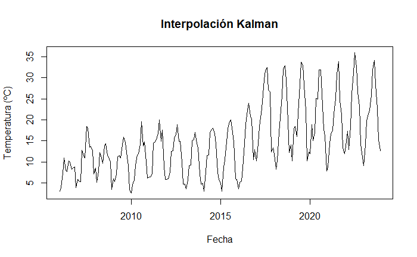

```r
# Método 4: Interpolación de Kalman
temp_ts_kalman <- na_kalman(temp_ts)
plot(temp_ts_kalman, main="Interpolación Kalman", ylab="Temperatura (ºC)", xlab="Fecha")
```

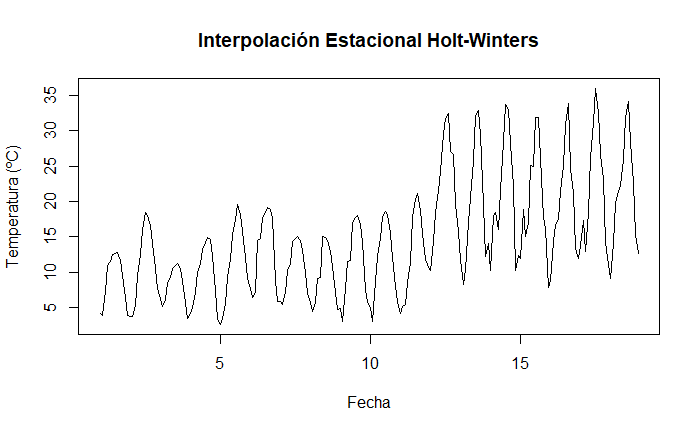

```r
# Método 5: Interpolación estacional de Holt-Winters
temp_ts_hw <- na_seadec(temp_ts, algorithm="interpolation", find_frequency=TRUE)
plot(temp_ts_hw, main="Interpolación Estacional Holt-Winters", ylab="Temperatura (ºC)", xlab="Fecha")
```

```r
NA
NA
```

### **Estudios de outliers o datos atípicos**

El estudio de los outliers (o valores atípicos) es una parte esencial del análisis de datos y la estadística. Un outlier es un dato que se encuentra significativamente alejado de la mayoría de los datos en un conjunto. Estos valores pueden ser resultado de variaciones en el sistema, errores de medición, errores de entrada de datos, o pueden ser indicativos de eventos raros pero significativos.

En el contexto de series temporales, la detección de outliers es especialmente relevante. Los datos de series temporales pueden contener outliers que representan eventos anómalos en el tiempo, como cambios repentinos en la tendencia, variaciones estacionales inesperadas, o puntos de datos que no siguen el patrón general de la serie.

El paquete tsoutliers en R se utiliza específicamente para la identificación y tratamiento de outliers en series temporales. Este paquete ofrece funciones para detectar automáticamente varios tipos de outliers, como:

AO (Additive Outliers): Puntos de datos inusualmente altos o bajos.

LS (Level Shifts): Cambios repentinos en el nivel de la serie.

TC (Temporary Changes): Cambios temporales que regresan a su nivel original después de algunos periodos.

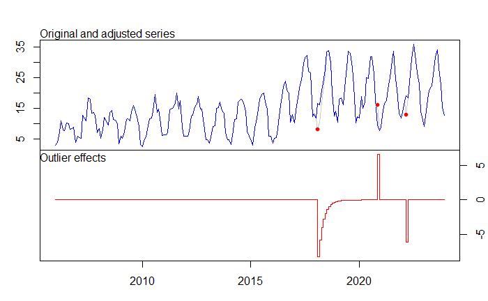

```r
temp.tsoutliers=tso(temp_ts_kalman ,types=c("AO","TC","LS","IO"),maxit.iloop =10)

plot(temp.tsoutliers)
```